# wk05_ggplot

Caio Faro

February 5, 2016

## joining data

For this portion of the individual assignment, similar to last week, you’ll find it easiest to copy and paste from `## joining data` onwards in [`env-info/wk05_joining.Rmd`](https://raw.githubusercontent.com/ucsb-bren/env-info/gh-pages/wk05_joining.Rmd) to your `<user>.github.io/env-info_hw/wk05_ggplot.Rmd`. Then you can play with different chunks of the code. Please be sure to answer all tasks and questions at the bottom.

The R chunks explaining the `dplyr` join functions below are pulled from the excellent **wrangling-webinar.pdf** presentation, which you should consult as you execute (see shortcuts in rstudio-IDE-cheatsheet.pdf).

### setup

Ensure that you’re in the same working directory `env-info_hw` when you Knit HTML as when you test code in the Console.

```r
wd = 'env-info_hw'

# set working directory for Console (vs Rmd)
if (wd %in% list.files() & interactive()){
    setwd(wd)
}

# ensure working directory
if (basename(getwd()) != wd){
  stop(sprintf("WHOAH! Your working directory is not in '%s'!\n   getwd(): %s", wd, getwd()))
}
```

### `bind_cols`

bind columns between data frames

```r
library(dplyr)
y = data.frame(
  x1 = c('A','B','C'),
  x2 = c( 1 , 2 , 3),
  stringsAsFactors=F)
z = data.frame(
  x1 = c('B','C','D'),
  x2 = c( 2 , 3 , 4),
  stringsAsFactors=F)
y
```

```
##   x1 x2
## 1  A  1
## 2  B  2
## 3  C  3
```

```r
z
```

```
##   x1 x2
## 1  B  2
## 2  C  3
## 3  D  4
```

```r
bind_cols(y, z)
```

```
## Source: local data frame [3 x 4]
##
##      x1    x2    x1    x2
##   (chr) (dbl) (chr) (dbl)
## 1     A     1     B     2
## 2     B     2     C     3
## 3     C     3     D     4
```

### `bind_rows`

bind rows of data frames

```r
y
```

```
##   x1 x2
## 1  A  1
## 2  B  2
## 3  C  3
```

```r
z
```

```
##   x1 x2
## 1  B  2
## 2  C  3
## 3  D  4
```

```r
bind_rows(y, z)
```

```
## Source: local data frame [6 x 2]
##
##      x1    x2
##   (chr) (dbl)
## 1     A     1
## 2     B     2
## 3     C     3
## 4     B     2
## 5     C     3
## 6     D     4
```

### `union`

set operation on data frames, returning all unique rows

```r
y
```

```
##   x1 x2
## 1  A  1
## 2  B  2
## 3  C  3
```

```r
z
```

```
##   x1 x2
## 1  B  2
## 2  C  3
## 3  D  4
```

```r
union(y, z)
```

```
##   x1 x2
## 1  B  2
## 2  A  1
## 3  C  3
## 4  D  4
```

### `intersect`

set operation on data frames, returning those rows in common

```r
y
```

```
##   x1 x2
## 1  A  1
## 2  B  2
## 3  C  3
```

```r
z
```

```
##   x1 x2
## 1  B  2
## 2  C  3
## 3  D  4
```

```r
intersect(y, z)
```

```
##   x1 x2
## 1  B  2
## 2  C  3
```

### `setdiff`

set operation on data frames, returning all mismatched rows

```r
y
```

```
##   x1 x2
## 1  A  1
## 2  B  2
## 3  C  3
```

```r
z
```

```
##   x1 x2
## 1  B  2
## 2  C  3
## 3  D  4
```

```r
setdiff(y, z)
```

```
##   x1 x2
## 1  A  1
```

### `left_join`

return all rows from x, and all columns from x and y. Rows in x with no match in y will have NA values in the new columns.

```r
songs = data.frame(
  song = c('Across the Universe','Come Together', 'Hello, Goodbye', 'Peggy Sue'),
  name = c('John','John','Paul','Buddy'),
  stringsAsFactors=F)
artists = data.frame(
  name = c('George','John','Paul','Ringo'),
  plays = c('sitar','guitar','bass','drums'),
  stringsAsFactors=F)
left_join(songs, artists, by='name')
```

```
##                  song  name  plays
## 1 Across the Universe  John guitar
## 2       Come Together  John guitar
## 3      Hello, Goodbye  Paul   bass
## 4           Peggy Sue Buddy   <NA>
```

### `inner_join`

return all rows from x where there are matching values in y, and all columns from x and y

```r
inner_join(songs, artists, by = "name")
```

```
##                  song name  plays
## 1 Across the Universe John guitar
## 2       Come Together John guitar
## 3      Hello, Goodbye Paul   bass
```

### `semi_join`

return all rows from x where there are matching values in y, keeping just columns from x

```r
semi_join(songs, artists, by = "name")
```

```
##                  song name
## 1 Across the Universe John
## 2       Come Together John
## 3      Hello, Goodbye Paul
```

### `anti_join`

return all rows from x where there are not matching values in y, keeping just columns from x

```r
anti_join(songs, artists, by = "name")
```

```
##        song  name
## 1 Peggy Sue Buddy
```

### per capita CO<sub>2</sub> emissions

You’ll join the population dataset to calculate per capita CO<sub>2</sub> emissions.

**Task**. Calculate the per capita emissions by country (not World or EU28) and return the top 5 emitting countries for **2014**.

```r
library(readr)
library(readxl) # install.packages('readxl')
library(dplyr)
library(tidyr)
library(httr)   # install.packages('httr')
library(plyr)   # install.packages('plyr')
print(getwd())
```

```
## [1] "C:/Users/Caio_Otto/Desktop/Bren School/Winter 16/Informatics/caio-faro.github.io/env-info_hw"
```

```r
# population Excel file
url = 'http://edgar.jrc.ec.europa.eu/news_docs/CO2_1970-2014_dataset_of_CO2_report_2015.xls'
out = './data/co2_europa.xls'
if (!file.exists(out)) writeBin(content(GET(url), 'raw'), out)

# country lookup csv file
url = 'https://raw.githubusercontent.com/ucsb-bren/env-info/gh-pages/data/co2_country_to_popn.csv'
out = './data/co2_country_to_popn.csv'
if (!file.exists(out)) writeBin(content(GET(url), 'raw'), out)


xls <- "./data/co2_europa.xls"

# read in carbon dioxide emissions file
co2 = read_excel(xls, skip=12)
```

[output not shown]

```r
Longco2 <- gather(co2, "Year", "Emissions", -Country) %>%
  mutate(Year = as.numeric(Year))

# get lookup table to translate some country names in popn to those in co2 table
cntry = read_csv('./data/co2_country_to_popn.csv')

# read in population and revalue some country names to match co2 table
popn = read_csv('https://raw.githubusercontent.com/datasets/population/master/data/population.csv') %>%
  select(Country=`Country Name`, Year=Year, popn=Value) %>%
  mutate(
    Country = plyr::revalue(
      Country,
      setNames(cntry$country_co2, cntry$country_popn)))

Table <- left_join(Longco2, popn, by = c("Country", "Year"))
```

```r
Task1 <- Table %>%
  mutate(PerCapita = Emissions/popn) %>%
  filter(Year == 2014, Country != "World", Country != "EU28") %>%
  arrange(desc(PerCapita))

head(Task1, n = 5)
```

```
## Source: local data frame [5 x 5]
##
##                Country  Year Emissions    popn  PerCapita
##                  (chr) (dbl)     (dbl)   (dbl)      (dbl)
## 1                Qatar  2014  88750.72 2267916 0.03913316
## 2               Kuwait  2014  98558.59 3479371 0.02832655
## 3  Trinidad and Tobago  2014  34017.47 1344235 0.02530619
## 4 United Arab Emirates  2014 201052.18 9445624 0.02128522
## 5                 Oman  2014  74288.47 3926492 0.01891981
```

**Task**. Summarize the per capita emissions by country (not World or EU28) as the mean (ie average) value across all years and return the top 5 emitting countries.

```r
detach("package:plyr", unload=TRUE)
SUMTask <- Table %>%
            filter(Country != "World", Country != "EU28") %>%
            mutate(PerCapita = Emissions/popn) %>%
            group_by(Country) %>%
            summarise(AveEmission = mean(PerCapita)) %>%
            arrange(desc(AveEmission))


head(SUMTask, n = 5)
```

```
## Source: local data frame [5 x 2]
##
##                Country AveEmission
##                  (chr)       (dbl)
## 1                Qatar  0.06285535
## 2 United Arab Emirates  0.04000397
## 3           Luxembourg  0.02944910
## 4              Bahrain  0.02109961
## 5              Estonia  0.02080460
```

## ggPlot

#### Individual

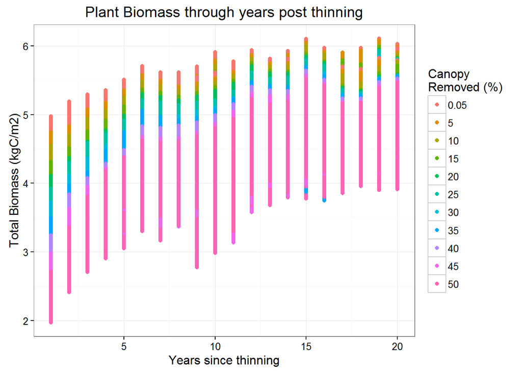

```r
require(ggplot2)
thin <- read_csv('./data/thinning.csv')

ThinPlot <- ggplot(thin, aes(x = postyears, y = plantc, col = as.factor(thin))) +
            geom_point() +
            theme_bw() +
            ggtitle("Plant Biomass through years post thinning") +
            labs(x = "Years since thinning", y = "Total Biomass (kgC/m2)", col = "Canopy\nRemoved (%)")


ThinPlot
```

#### Group

The ggplot made with Group data can be found [here](http://fishmgt.github.io/wk05_ggplot_CF.html).